# Coursera’s Statistical Inference Final Project Part - I, Simulation Exercise

Jorge Mendoza

August 11, 2017

## Overview

On this report we will provide the results of a simulation excersice to investigate the exponential distribution using R and make theorical comparasions with the Central Limit or CLT.

According to the CLT (https://en.wikipedia.org/wiki/Central_limit_theorem), if a sample has at least 30 independant observations and assuming that the observations are independent (not strongly related), the distribution sample mean will behavie approximatedly to the normal distrubution, ruled by the math function:

$\bar{x}_{n}$ ~ $N(\mu, \frac{\sigma }{\sqrt{n}})$.

In order to simulate the exponential distribution using R we will run the function `rexp(n, lambda)`, with the given data:

$n = 40$ $\lambda = 0.2$

And compare this values with the given function for the Normal distribution $\bar{N}$

$N(\frac{1}{0.2}, \frac{\frac{1}{0.2}}{\sqrt{40}})$

Now let’s run a 1000 simulations with 40 elements each, rule by the Exponential distribution.

$Exp(\frac{1}{0.2}, \frac{1}{0.2})$

And let’s calculate the mean of each of those 1000 exponential distributions with size 40. Based on the CLT the mean of those 1000 simulations would be close to $\frac{1}{\lambda} = \frac{1}{0.2} = 5$ according to the Normal distribution

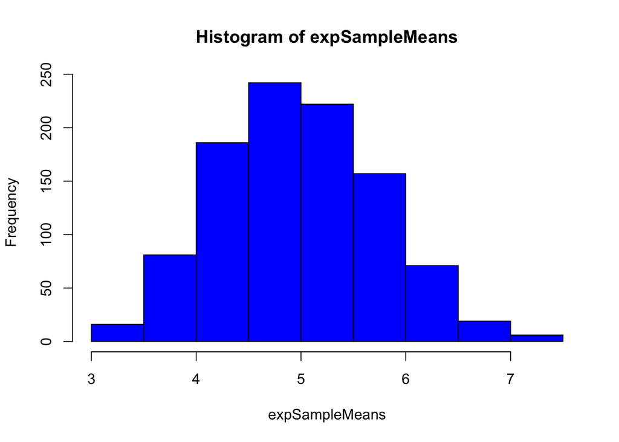

```r
library(ggplot2)
set.seed(1234)

lambda <- 0.2
n <- 40
sim <- 1000
expSampleMeans <- NULL

for (i in 1:sim){
  expSampleMeans <- c(expSampleMeans, mean(rexp(n, lambda)))
}

sampleMean <- mean(expSampleMeans)
sampleStandar_deviation <- sd(expSampleMeans)
sampleVariance <- var(expSampleMeans)

hist(expSampleMeans, col = "blue")
```

```r
round(mean(expSampleMeans), 2)
```

```
## [1] 4.97
```

```r
var <- (1 / lambda)^2 / (n)
mu <- 1/lambda

mu
```

```
## [1] 5
```

```r
var
```

```
## [1] 0.625
```

```r
round(mean(sampleVariance), 2)
```

```
## [1] 0.57
```

## Sample Distribution and Normal Distribution

Both the mean of the sample and its variance are close to the theorical values (mean and variance) of the normal distribution.

In order to take a closer look at this values, lets now create a plot that contains both the sample means with a vertical line on its mean and lets overlap the normal distribution curve over those same values and another vertical line that shows the normal distribution mean (in red)

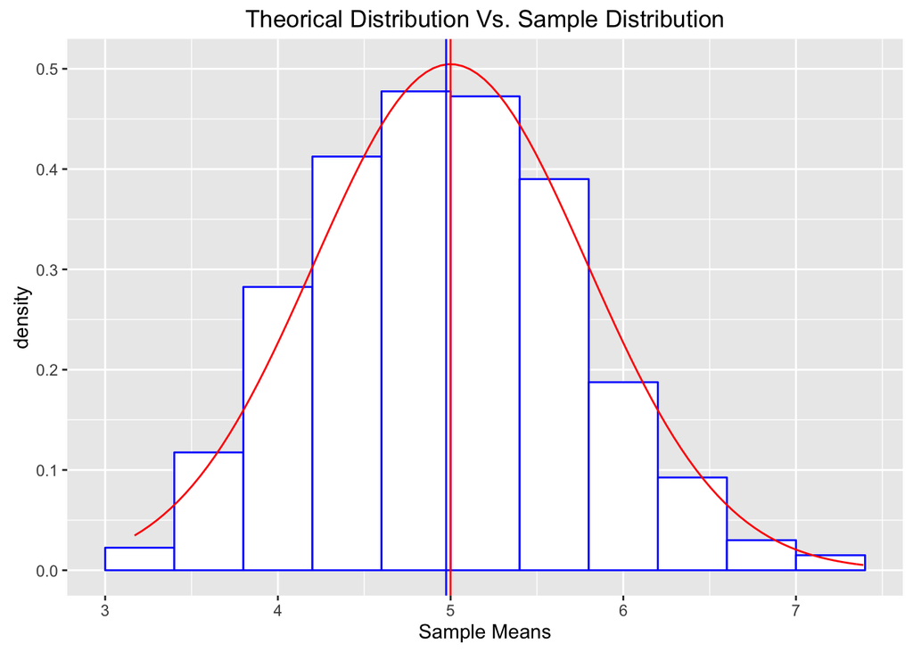

```r
data <- as.data.frame(expSampleMeans)
plot <- ggplot(data, aes(x = expSampleMeans));
plot <- plot + geom_histogram(binwidth = 0.4, color = 'blue', fill = 'white', aes(y = ..density..))
plot <- plot + stat_function(fun = dnorm, color = 'red', args = list(mean = 5, sd = sqrt(0.625)))
plot <- plot + geom_vline(xintercept = mean(expSampleMeans), color="blue");
plot <- plot + geom_vline(xintercept = mu, color="red");
plot <- plot + labs(colour = "Blue")
plot <- plot + labs(x = "Sample Means")
plot <- plot + labs(title = "Theorical Distribution Vs. Sample Distribution")

plot
```

## Conclusions

The data fits in the normal distribution curve, as it migth be appreciated in the previous graph. To be more specific we migth stand that with the given conditions Exponential distribution, $n = 40$ and $\lambda = 0.2$

The distribution is approximately to $N(\frac{1}{0.2}, \frac{\frac{1}{0.2}}{\sqrt{40}})$